# Forecasting the Volatility of Cryptocurrencies in the Presence of COVID-19 with the State Space Model and Kalman Filter

Alexandre Rabhi

2024-12-29

# PART 1: Environment set up

## 1.1- Required packages installation

```r
packages <- c(
  "tseries", "zoo", "moments", "car", "MASS", "stats", "fGarch",
  "PerformanceAnalytics", "rugarch", "tidyverse", "xts", "forecast",
  "scales", "e1071", "xtable", "quantmod", "KFAS", "fpp2", "tidyquant",
  "ggplot2", "kableExtra", "knitr"
)

install_and_load <- function(packages) {
  for (pkg in packages) {
    if (!require(pkg, character.only = TRUE)) {
      install.packages(pkg, dependencies = TRUE)
      library(pkg, character.only = TRUE)
    }
  }
}
install_and_load(packages)
```

## 1.2- Package required importation

```r
require("tseries")
require("zoo")
require("moments")
require("car")
require("MASS")
require("stats")
require("fGarch")
require("PerformanceAnalytics")
require("rugarch")
library(tidyverse)
library(xts)
library(forecast)
library(scales)
library(e1071)
library(xtable)
library(quantmod)
library(KFAS)
library(fpp2)
library(tidyquant)

library(ggplot2)
library(kableExtra)
library(knitr)
```

## 1.3- Progamming environnement configuration

```r
setwd("C:/Users/rabhi/Documents/Master 272 IEF - Dauphine/M2/S1/Gestion quantitative/Soutenance/volatility_forecasting_project")

rm(list=ls(all=TRUE)) # Remove objects from environment
options(warn=-1)
```

# PART 2: Data importation and managamenet

## 2.1- Close prices et returns extraction

**BTC/USD**

```r
BTC_h <- read.csv("BTC.csv")
BTC_h$datetime <- as.POSIXct(BTC_h$unix, origin = "1970-01-01", tz = "GMT")

start_date <- as.POSIXct("2020-02-26 00:00:00", tz = "GMT")
end_date <- as.POSIXct("2021-04-18 00:00:00", tz = "GMT")

filtered_data <- BTC_h[BTC_h$datetime >= start_date & BTC_h$datetime <= end_date, ]

BTC_close <- ts(
  filtered_data$close,
  start = c(2020, as.numeric(format(start_date, "%j"))),
  frequency = 24 * 365
)

BTC_returns <- diff(log(BTC_close))
BTC_returns <- tail(BTC_returns,10000)
```

**ETH/USD**

```r
ETH_h <- read.csv("ETH.csv")
ETH_h$datetime <- as.POSIXct(ETH_h$unix, origin = "1970-01-01", tz = "GMT")

ETH_h <- ETH_h[order(ETH_h$datetime), ]

filtered_data <- ETH_h[ETH_h$datetime >= start_date & ETH_h$datetime <= end_date, ]

ETH_close <- ts(
  filtered_data$close,
  start = c(2020, as.numeric(format(start_date, "%j"))),
  frequency = 24 * 365
)

ETH_returns <- diff(log(ETH_close))
ETH_returns <- tail(ETH_returns,10000)
```

**LTC/USD**

```r
LTC_h <- read.csv("LTC.csv")
LTC_h$datetime <- as.POSIXct(LTC_h$unix, origin = "1970-01-01", tz = "GMT")

LTC_h <- LTC_h[order(LTC_h$datetime), ]

filtered_data <- LTC_h[LTC_h$datetime >= start_date & LTC_h$datetime <= end_date, ]

LTC_close <- ts(
  filtered_data$close,
  start = c(2020, as.numeric(format(start_date, "%j"))),
  frequency = 24 * 365
)

LTC_returns <- diff(log(LTC_close))
LTC_returns <- tail(LTC_returns,10000)
```

**XRP/USD**

```r
XRP_h <- read.csv("XRP.csv")
XRP_h$datetime <- as.POSIXct(XRP_h$unix, origin = "1970-01-01", tz = "GMT")

XRP_h <- XRP_h[order(XRP_h$datetime), ]

filtered_data <- XRP_h[XRP_h$datetime >= start_date & XRP_h$datetime <= end_date, ]

XRP_close <- ts(
  filtered_data$close,
  start = c(2020, as.numeric(format(start_date, "%j"))),
  frequency = 24 * 365
)

XRP_returns <- diff(log(XRP_close))
XRP_returns <- tail(XRP_returns,10000)
```

**BCH/USD**

```r
BCH_h <- read.csv("BCH.csv")
BCH_h$datetime <- as.POSIXct(BCH_h$unix, origin = "1970-01-01", tz = "GMT")

BCH_h <- BCH_h[order(BCH_h$datetime), ]

filtered_data <- BCH_h[BCH_h$datetime >= start_date & BCH_h$datetime <= end_date, ]

BCH_close <- ts(
  filtered_data$close,
  start = c(2020, as.numeric(format(start_date, "%j"))),
  frequency = 24 * 365
)

BCH_returns <- diff(log(BCH_close))
BCH_returns <- tail(BCH_returns,10000)
```

## 2.2- Observed volatility extraction

The centred log return is calculated by implying the following formula on the asset returns:
$$r_t^* = \frac{r_t - \bar{r}}{\rho},$$
where $r_t$ is the log return, $\bar{r}$ is the mean of $r_t$, and
$$\rho = \frac{\mu_{| r_t - \bar{r}|}}{\sigma_{r_t}}.$$
where $\mu_{| r_t - \bar{r}|}$ is the mean of $| r_t - \bar{r}|$ and $\sigma_{r_t}$ is the standard deviation of $r_t$.

```r
observed_volatility <- function(returns) {
  sigma_returns <- sd(returns)
  excess_returns <- returns - mean(returns)
  abs_excess_returns <- abs(excess_returns)
  mu <- mean(abs_excess_returns)
  rho <- mu / sigma_returns
  observed_volatility <- ts(abs_excess_returns/rho)
  return(observed_volatility)
}
```

By using this function we can compute and then display the observed volatility of Bitcoin, Ether, Litecoin, Ripples and Bitcoin Cash.

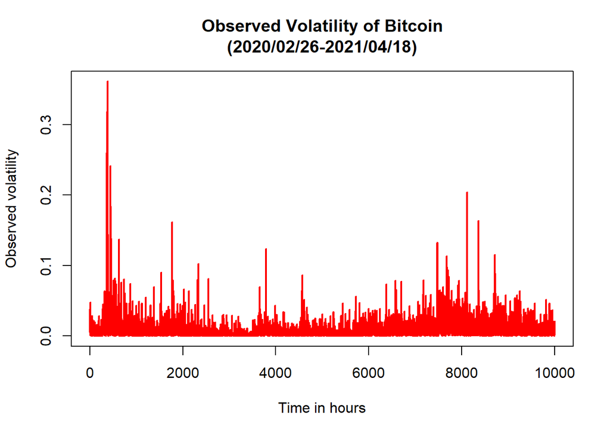

```r
BTC_observed_volatility <- observed_volatility(BTC_returns)
plot(BTC_observed_volatility,
     main = "Observed Volatility of Bitcoin\n(2020/02/26-2021/04/18)",
     xlab = "Time in hours",
     ylab = "Observed volatility",
     col = "red",
     lwd = 2)
```

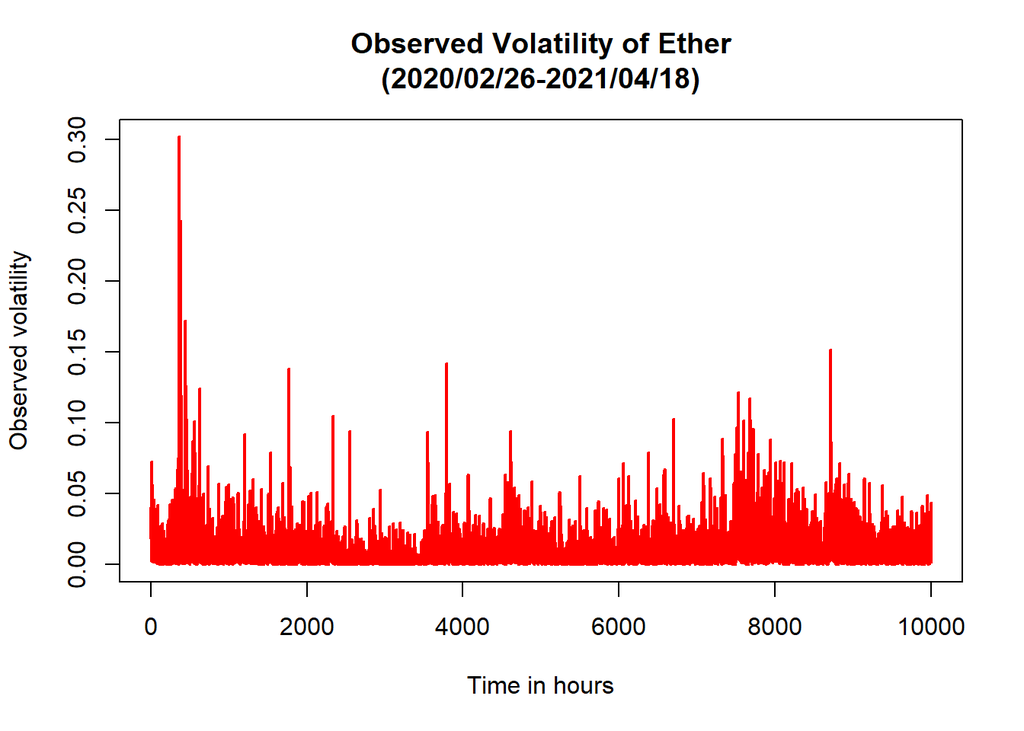

```r
ETH_observed_volatility <- observed_volatility(ETH_returns)
plot(ETH_observed_volatility,
     main = "Observed Volatility of Ether\n(2020/02/26-2021/04/18)",
     xlab = "Time in hours",
     ylab = "Observed volatility",
     col = "red",
     lwd = 2)
```

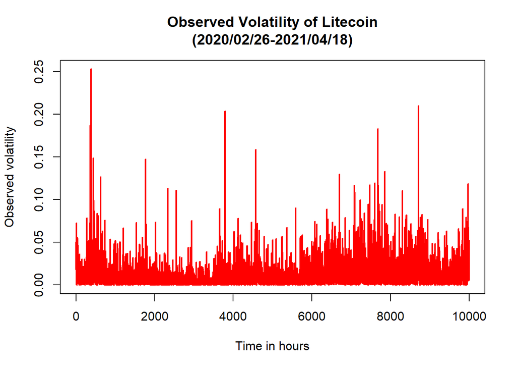

```r
LTC_observed_volatility <- observed_volatility(LTC_returns)
plot(LTC_observed_volatility,
     main = "Observed Volatility of Litecoin\n(2020/02/26-2021/04/18)",
     xlab = "Time in hours",
     ylab = "Observed volatility",
     col = "red",
     lwd = 2)
```

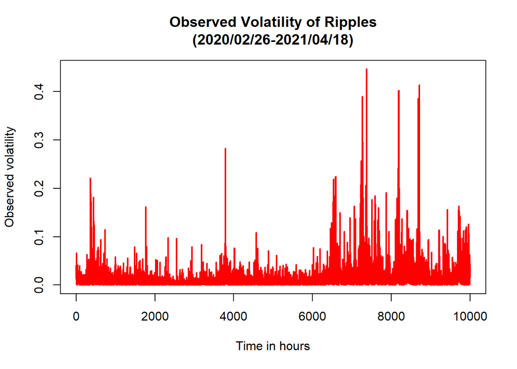

```r
XRP_observed_volatility <- observed_volatility(XRP_returns)
plot(XRP_observed_volatility,
     main = "Observed Volatility of Ripples\n(2020/02/26-2021/04/18)",
     xlab = "Time in hours",
     ylab = "Observed volatility",
     col = "red",
     lwd = 2)
```

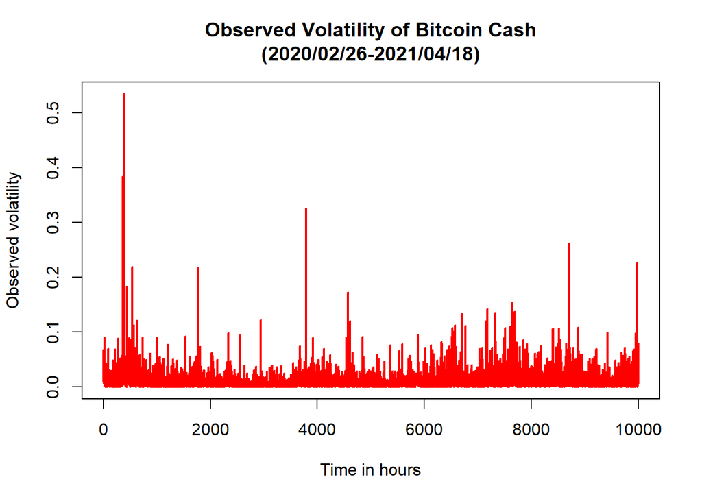

```r
BCH_observed_volatility <- observed_volatility(BCH_returns)
plot(BCH_observed_volatility,
     main = "Observed Volatility of Bitcoin Cash\n(2020/02/26-2021/04/18)",
     xlab = "Time in hours",
     ylab = "Observed volatility",
     col = "red",
     lwd = 2)
```

## 2.3- Descriptive statistics computations

We create a function to calculate the core descriptive statistics of a time series of returns.

```r
descriptive_statistics <- function(returns) {
  returns_skewness <- skewness(returns, na.rm = TRUE, type = 1)
  returns_std <- sd(returns, na.rm = TRUE)
  returns_kurtosis <- kurtosis(returns, na.rm = TRUE, type = 1)
  returns_maximum <- max(returns, na.rm = TRUE)
  returns_minimum <- min(returns, na.rm = TRUE)
  returns_mean <- mean(returns, na.rm = TRUE)
  returns_median <- median(returns, na.rm = TRUE)

  return(c(
    Maximum = returns_maximum,
    Minimum = returns_minimum,
    Mean = returns_mean,
    Median = returns_median,
    `Standard Deviation` = returns_std,
    Skewness = returns_skewness,
    Kurtosis = returns_kurtosis
  ))
}
```

Now we can compute the statistics of the different cryptocurrencies and display them in a table.

```r
BTC_stats <- descriptive_statistics(BTC_returns)
ETH_stats <- descriptive_statistics(ETH_returns)
LTC_stats <- descriptive_statistics(LTC_returns)
XRP_stats <- descriptive_statistics(XRP_returns)
BCH_stats <- descriptive_statistics(BCH_returns)

crypto_stats <- data.frame(
  rbind(BTC_stats, ETH_stats, LTC_stats, XRP_stats, BCH_stats)
)

crypto_stats %>%
  kbl(caption = "Descriptive Statistics") %>%
  kable_styling(full_width = FALSE, position = "center")
```

Descriptive Statistics

|  | Maximum | Minimum | Mean | Median | Standard.Deviation | Skewness | Kurtosis |
| --- | --- | --- | --- | --- | --- | --- | --- |
| BTC_stats | 0.2054827 | -0.1809033 | 0.0001869 | 0.0001821 | 0.0092331 | -0.2193474 | 68.10342 |
| ETH_stats | 0.1514337 | -0.1881965 | 0.0002270 | 0.0002516 | 0.0108454 | -0.8573528 | 27.84062 |
| LTC_stats | 0.1606554 | -0.1331406 | 0.0001487 | 0.0001634 | 0.0120843 | -0.3373762 | 16.04084 |
| XRP_stats | 0.2438025 | -0.2252537 | 0.0001843 | 0.0000000 | 0.0154385 | -0.0674344 | 37.02531 |
| BCH_stats | 0.3145738 | -0.2255503 | 0.0001113 | 0.0001292 | 0.0127790 | 0.1279137 | 67.77190 |

# PART 3: Data modelling (GARCH, SS-KF and NNAR)

## 3.1- GARCH(1,1) model

We create a function to fit a GARCH(1,1) model on the log-returns and to compute the one-step forecast as well as the mae and the rmse.

```r
garch11_fit <- function(returns,observed_volatility){
  garch_model <- ugarchspec(mean.model=list(armaOrder=c(0,0)),
                       variance.model=list(garchOrder=c(1,1)),
                       distribution.model = "std")

  fitted_model <- ugarchfit(data=returns, spec=garch_model)

  fitted_values <- sigma(fitted_model)

  prediction <- ugarchforecast(fitted_model, data=BTC_returns, n.ahead=1)

  prediction <- sigma(prediction)

  residuals <- as.vector(observed_volatility) - as.vector(sigma(fitted_model))

  mae<-mean(abs(residuals))

  rmse<-sqrt(mean(residuals^2))

  return(list(
    Model = fitted_model,
    Fitted_values = fitted_values,
    Residuals = residuals,
    Forecast = prediction,
    MAE = mae,
    RMSE = rmse
  ))
}
```

The model is fitted on the log-returns of **BTC/USD**, used to make a one-step forecast and the mae/rmse.

```r
BTC_garch_info <- garch11_fit(BTC_returns,BTC_observed_volatility)
```

The model is fitted on the log-returns of **ETH/USD**, used to make a one-step forecast and the mae/rmse.

```r
ETH_garch_info <- garch11_fit(ETH_returns,ETH_observed_volatility)
```

The model is fitted on the log-returns of **LTC/USD**, used to make a one-step forecast and the mae/rmse.

```r
LTC_garch_info <- garch11_fit(LTC_returns,LTC_observed_volatility)
```

The model is fitted on the log-returns of **XRP/USD**, used to make a one-step forecast and the mae/rmse.

```r
XRP_garch_info <- garch11_fit(XRP_returns,XRP_observed_volatility)
```

The model is fitted on the log-returns of **BCH/USD**, used to make a one-step forecast and the mae/rmse.

```r
BCH_garch_info <- garch11_fit(BCH_returns,BCH_observed_volatility)
```

## 3.2- ARIMA State-Space model with Kalman Filter

Since the optimal integration order $d$ is determned by using the repeated Kwiatkowski–Phillips–Schmidt–Shin (KPSS) test, we construct a function to apply this algorithm.

```r
optimal_integration_order <- function(time_series, max_order = 2, alpha = 0.05) {

  order_of_integration <- 0

  kpss_test <- function(series) {
    test_result <- kpss.test(series, null = "Level")
    return(test_result$p.value)
  }

  p_value <- kpss_test(time_series)
  if (p_value < alpha) {
    for (order in 1:max_order) {
      diff_series <- diff(time_series, differences = order)
      p_value <- kpss_test(diff_series)
      if (p_value >= alpha) {
        order_of_integration <- order
        break
      }
    }
  }

  return(order_of_integration)
}
```

Now we can create a function to fit an arima state space model with a Kalman Filter on the log-returns and to compute the one-step forecast as well as the mae and the rmse of the model.

```r
ss_kf_fit <- function(returns,observed_volatility){

  optimal_d <- optimal_integration_order(returns,max_order=3,alpha=0.01)

  model = auto.arima(as.vector(returns),d=optimal_d)

  ar_coef <- model$coef[grep("^ar", names(model$coef))]

  ss_model_arima <- SSModel(observed_volatility ~ SSMarima(d=optimal_d, ar=ar_coef))

  out<- KFS(ss_model_arima)

  fitted_values <- as.matrix(out$a)

  fitted_values <- fitted_values[2:10001,1]

  prediction <- coredata((predict(out$model, n.ahead=1)))

  residuals <- as.vector(observed_volatility) - fitted_values

  mae<-mean(abs(residuals))

  rmse<-sqrt(mean(residuals^2))

  return(list(
        Model = ss_model_arima,
        Fitted_values = fitted_values,
        Residuals = residuals,
        Forecast = prediction,
        MAE = mae,
        RMSE = rmse
  ))
}
```

The model is fitted on the log-returns of **BTC/USD**, used to make a one-step forecast and the mae/rmse.

```r
BTC_SSKF_info <- ss_kf_fit(BTC_returns,BTC_observed_volatility)
```

The model is fitted on the log-returns of **ETH/USD**, used to make a one-step forecast and the mae/rmse.

```r
ETH_SSKF_info <- ss_kf_fit(ETH_returns,ETH_observed_volatility)
```

The model is fitted on the log-returns of **LTC/USD**, used to make a one-step forecast and the mae/rmse.

```r
LTC_SSKF_info <- ss_kf_fit(LTC_returns,LTC_observed_volatility)
```

The model is fitted on the log-returns of **XRP/USD**, used to make a one-step forecast and the mae/rmse.

```r
XRP_SSKF_info <- ss_kf_fit(XRP_returns,XRP_observed_volatility)
```

The model is fitted on the log-returns of **BCH/USD**, used to make a one-step forecast and the mae/rmse.

```r
BCH_SSKF_info <- ss_kf_fit(BCH_returns,BCH_observed_volatility)
```

## 3.4- Neural Network AutoRegressive model (NNAR)

```r
nnar_fit <- function(returns,observed_volatility){

  fitted_model <- nnetar(observed_volatility)

  prediction <- coredata(forecast(fitted_model, h=1)$mean)

  residuals <- as.vector(na.omit(fitted_model$residuals))

  mae<-mean(abs(residuals))

  rmse<-sqrt(mean(residuals^2))

  return(list(
        Model = fitted_model,
        Residuals = residuals,
        Forecast = prediction,
        MAE = mae,
        RMSE = rmse
  ))
}
```

```r
BTC_NNAR_info <- nnar_fit(BTC_returns,BTC_observed_volatility)
```

```r
ETH_NNAR_info <- nnar_fit(ETH_returns,ETH_observed_volatility)
```

```r
LTC_NNAR_info <- nnar_fit(LTC_returns,LTC_observed_volatility)
```

```r
XRP_NNAR_info <- nnar_fit(XRP_returns,XRP_observed_volatility)
```

```r
BCH_NNAR_info <- nnar_fit(BCH_returns,BCH_observed_volatility)
```

## 3.5- Models performance comparison

**RMSE & MAE**

```r
data <- data.frame(
  MODEL = c("GARCH (1,1)", "ARIMA-SS-KF", "NNAR"),
  "BTC RMSE" = c(BTC_garch_info$RMSE, BTC_SSKF_info$RMSE, BTC_NNAR_info$RMSE),
  "BTC MAE" = c(BTC_garch_info$MAE, BTC_SSKF_info$MAE, BTC_NNAR_info$MAE),

  "ETH RMSE" = c(ETH_garch_info$RMSE, ETH_SSKF_info$RMSE, ETH_NNAR_info$RMSE),
  "ETH MAE" = c(ETH_garch_info$MAE, ETH_SSKF_info$MAE, ETH_NNAR_info$MAE),

  "LTC RMSE" = c(LTC_garch_info$RMSE, LTC_SSKF_info$RMSE, LTC_NNAR_info$RMSE),
  "LTC MAE" = c(LTC_garch_info$MAE, LTC_SSKF_info$MAE, LTC_NNAR_info$MAE),

  "XRP RMSE" = c(XRP_garch_info$RMSE, XRP_SSKF_info$RMSE, XRP_NNAR_info$RMSE),
  "XRP MAE" = c(XRP_garch_info$MAE, XRP_SSKF_info$MAE, XRP_NNAR_info$MAE),

  "BCH RMSE" = c(BCH_garch_info$RMSE, BCH_SSKF_info$RMSE, BCH_NNAR_info$RMSE),
  "BCH MAE" = c(BCH_garch_info$MAE, BCH_SSKF_info$MAE, BCH_NNAR_info$MAE),
  check.names = FALSE
)

kable(data, digits = 4, align = "c", caption = "Lowest RMSE and MAE values for each dataset are bolded.") %>%
  kable_styling(full_width = FALSE, position = "center") %>%
  column_spec(2:11, width = "1.5cm") %>%
  add_header_above(c(" " = 1, "BTC" = 2, "ETH" = 2, "LTC" = 2, "XRP" = 2, "BCH" = 2)) %>%
  row_spec(3, bold = TRUE) %>%
  footnote(general = "Lowest RMSE and MAE values for each dataset are bolded.")
```

Lowest RMSE and MAE values for each dataset are bolded.

| MODEL | BTC BTC RMSE | BTC BTC MAE | ETH ETH RMSE | ETH ETH MAE | LTC LTC RMSE | LTC LTC MAE | XRP XRP RMSE | XRP XRP MAE | BCH BCH RMSE | BCH BCH MAE |
| --- | --- | --- | --- | --- | --- | --- | --- | --- | --- | --- |
| GARCH (1,1) | 0.0121 | 0.0061 | 0.0124 | 0.0073 | 0.0135 | 0.0080 | 0.0208 | 0.0101 | 0.0163 | 0.0086 |
| ARIMA-SS-KF | 0.0134 | 0.0077 | 0.0136 | 0.0087 | 0.0147 | 0.0093 | 0.0237 | 0.0120 | 0.0176 | 0.0102 |
| NNAR | 0.0099 | 0.0056 | 0.0110 | 0.0071 | 0.0122 | 0.0077 | 0.0158 | 0.0089 | 0.0133 | 0.0076 |

Note:  
Lowest RMSE and MAE values for each dataset are bolded.

**BTC/USD**

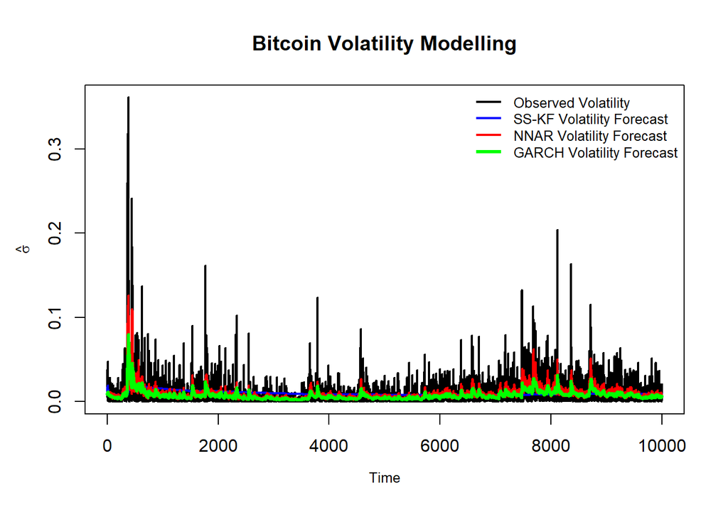

```r
time <- seq(from = 1, to = length(BTC_observed_volatility), by = 1)

# Observed volatility
plot(BTC_observed_volatility,
     main = "Bitcoin Volatility Modelling",
     lwd = 2,
     col = "black",
     ylab = "",
     xlab = "")

# ARIMA State-Space Model avec le filtre de Kalman
lines(time, BTC_SSKF_info$Fitted_values, lwd = 2, col = "blue")

# Modèle NNAR
lines(time, BTC_NNAR_info$Model$fitted, lwd = 2, col = "red")

# Modèle GARCH
lines(time, BTC_garch_info$Fitted_values, lwd = 3, col = "green")

# Ajout des labels pour les axes
mtext("Time", side = 1, line = 2.5, cex = 0.8)
mtext(expression(hat(sigma)), side = 2, line = 2.5, cex = 0.8)

legend("topright",
       legend = c("Observed Volatility", "SS-KF Volatility Forecast", "NNAR Volatility Forecast", "GARCH Volatility Forecast"),
       col = c("black", "blue", "red", "green"),
       lwd = c(2, 2, 2, 3),
       bty = "n",
       cex = 0.8)
```

**ETH/USD**

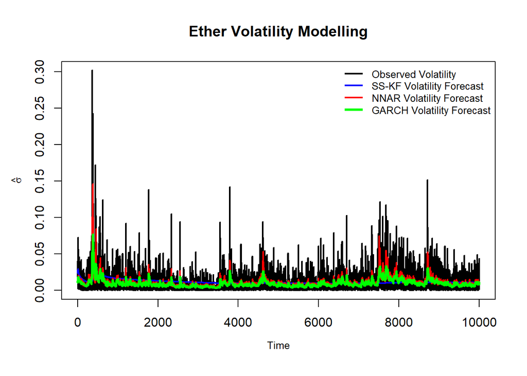

```r
time <- seq(from = 1, to = length(ETH_observed_volatility), by = 1)

# Observed volatility
plot(ETH_observed_volatility,
     main = "Ether Volatility Modelling",
     lwd = 2,
     col = "black",
     ylab = "",
     xlab = "")

# ARIMA State-Space Model avec le filtre de Kalman
lines(time, ETH_SSKF_info$Fitted_values, lwd = 2, col = "blue")

# Modèle NNAR
lines(time, ETH_NNAR_info$Model$fitted, lwd = 2, col = "red")

# Modèle GARCH
lines(time, ETH_garch_info$Fitted_values, lwd = 3, col = "green")

# Ajout des labels pour les axes
mtext("Time", side = 1, line = 2.5, cex = 0.8)
mtext(expression(hat(sigma)), side = 2, line = 2.5, cex = 0.8)

legend("topright",
       legend = c("Observed Volatility", "SS-KF Volatility Forecast", "NNAR Volatility Forecast", "GARCH Volatility Forecast"),
       col = c("black", "blue", "red", "green"),
       lwd = c(2, 2, 2, 3),
       bty = "n",
       cex = 0.8)
```

**LTC/USD**

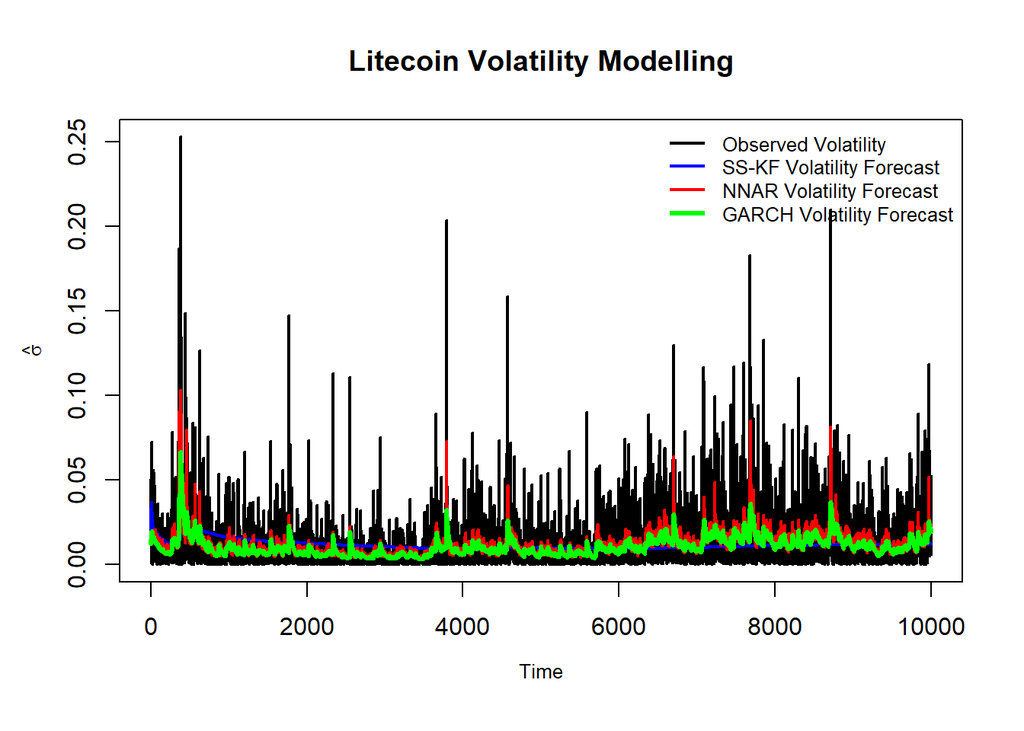

```r
time <- seq(from = 1, to = length(LTC_observed_volatility), by = 1)

# Observed volatility
plot(LTC_observed_volatility,
     main = "Litecoin Volatility Modelling",
     lwd = 2,
     col = "black",
     ylab = "",
     xlab = "")

# ARIMA State-Space Model avec le filtre de Kalman
lines(time, LTC_SSKF_info$Fitted_values, lwd = 2, col = "blue")

# Modèle NNAR
lines(time, LTC_NNAR_info$Model$fitted, lwd = 2, col = "red")

# Modèle GARCH
lines(time, LTC_garch_info$Fitted_values, lwd = 3, col = "green")

# Ajout des labels pour les axes
mtext("Time", side = 1, line = 2.5, cex = 0.8)
mtext(expression(hat(sigma)), side = 2, line = 2.5, cex = 0.8)

legend("topright",
       legend = c("Observed Volatility", "SS-KF Volatility Forecast", "NNAR Volatility Forecast", "GARCH Volatility Forecast"),
       col = c("black", "blue", "red", "green"),
       lwd = c(2, 2, 2, 3),
       bty = "n",
       cex = 0.8)
```

**XRP/USD**

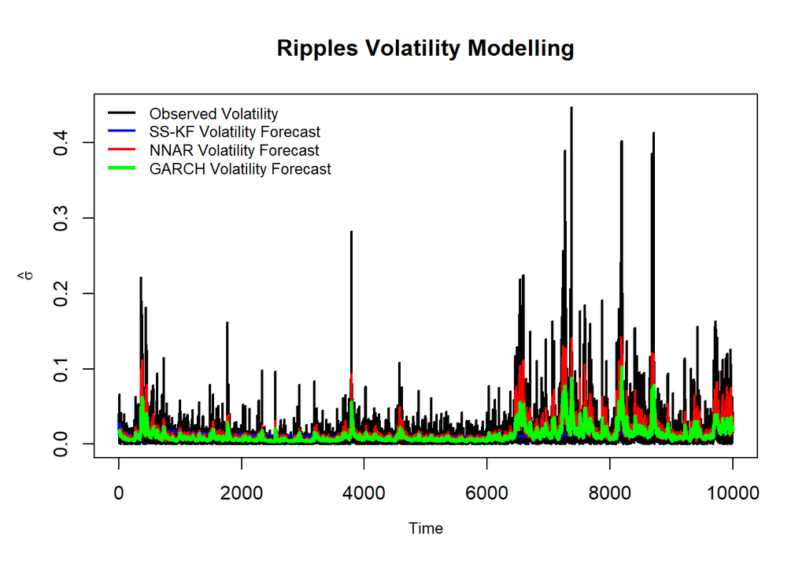

```r
time <- seq(from = 1, to = length(XRP_observed_volatility), by = 1)

# Observed volatility
plot(XRP_observed_volatility,
     main = "Ripples Volatility Modelling",
     lwd = 2,
     col = "black",
     ylab = "",
     xlab = "")

# ARIMA State-Space Model avec le filtre de Kalman
lines(time, XRP_SSKF_info$Fitted_values, lwd = 2, col = "blue")

# Modèle NNAR
lines(time, XRP_NNAR_info$Model$fitted, lwd = 2, col = "red")

# Modèle GARCH
lines(time, XRP_garch_info$Fitted_values, lwd = 3, col = "green")

# Ajout des labels pour les axes
mtext("Time", side = 1, line = 2.5, cex = 0.8)
mtext(expression(hat(sigma)), side = 2, line = 2.5, cex = 0.8)

legend("topleft",
       legend = c("Observed Volatility", "SS-KF Volatility Forecast", "NNAR Volatility Forecast", "GARCH Volatility Forecast"),
       col = c("black", "blue", "red", "green"),
       lwd = c(2, 2, 2, 3),
       bty = "n",
       cex = 0.8)
```

**BCH/USD**

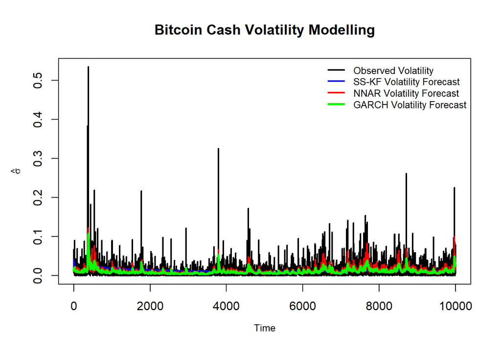

```r
time <- seq(from = 1, to = length(BCH_observed_volatility), by = 1)

# Observed volatility
plot(BCH_observed_volatility,
     main = "Bitcoin Cash Volatility Modelling",
     lwd = 2,
     col = "black",
     ylab = "",
     xlab = "")

# ARIMA State-Space Model avec le filtre de Kalman
lines(time, BCH_SSKF_info$Fitted_values, lwd = 2, col = "blue")

# Modèle NNAR
lines(time, BCH_NNAR_info$Model$fitted, lwd = 2, col = "red")

# Modèle GARCH
lines(time, BCH_garch_info$Fitted_values, lwd = 3, col = "green")

# Ajout des labels pour les axes
mtext("Time", side = 1, line = 2.5, cex = 0.8)
mtext(expression(hat(sigma)), side = 2, line = 2.5, cex = 0.8)

legend("topright",
       legend = c("Observed Volatility", "SS-KF Volatility Forecast", "NNAR Volatility Forecast", "GARCH Volatility Forecast"),
       col = c("black", "blue", "red", "green"),
       lwd = c(2, 2, 2, 3),
       bty = "n",
       cex = 0.8)
```

# PART 4: Residuals study

## 4.1- GARCH Models residuals

**BTC/USD**

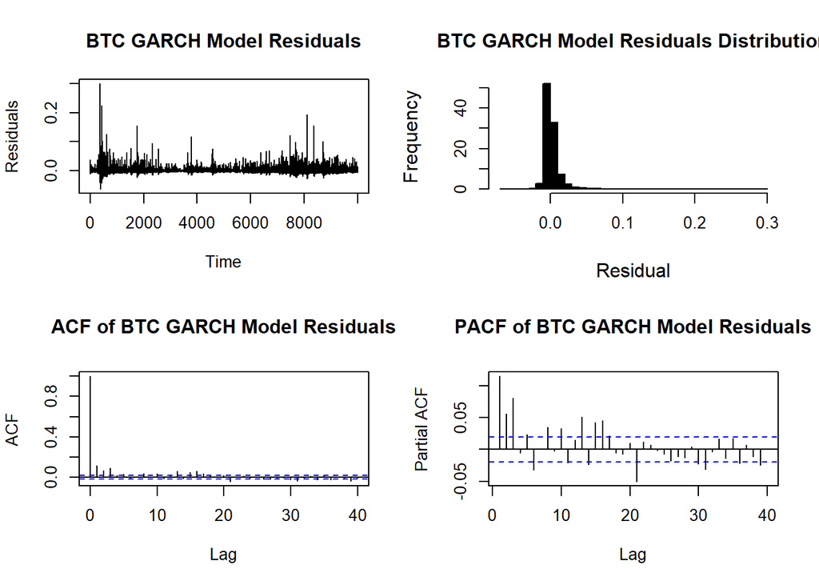

```r
par(mfrow = c(2, 2))

plot(BTC_garch_info$Residuals, type = "l", xlab="Time", ylab="Residuals", main="BTC GARCH Model Residuals")
hist(BTC_garch_info$Residuals, main = "BTC GARCH Model Residuals Distribution", breaks=50, col="black", prob=TRUE, xlab="", ylab="")
mtext("Frequency", side=2, line=3.5, cex=1)
mtext("Residual", side=1, line=3.5, cex=1, outer=FALSE)
acf(BTC_garch_info$Residuals, main = "ACF of BTC GARCH Model Residuals", cex.axis=1, cex.lab=1)
pacf(BTC_garch_info$Residuals, main = "PACF of BTC GARCH Model Residuals", cex.axis=1, cex.lab=1)
```

```r
par(mfrow = c(1, 1))
```

**ETH/USD**

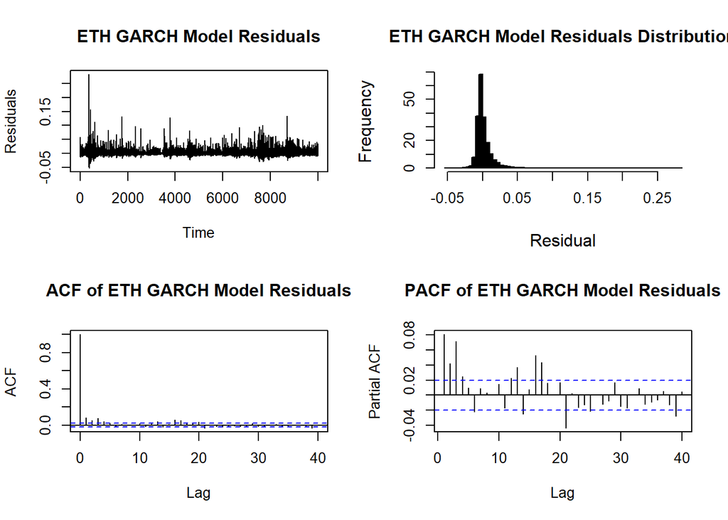

```r
par(mfrow = c(2, 2))

plot(ETH_garch_info$Residuals, type = "l", xlab = "Time", ylab = "Residuals", main = "ETH GARCH Model Residuals")
hist(ETH_garch_info$Residuals, main = "ETH GARCH Model Residuals Distribution", breaks = 50, col = "black", prob = TRUE, xlab = "", ylab = "")
mtext("Frequency", side = 2, line = 3.5, cex = 1)
mtext("Residual", side = 1, line = 3.5, cex = 1, outer = FALSE)
acf(ETH_garch_info$Residuals, main = "ACF of ETH GARCH Model Residuals", cex.axis = 1, cex.lab = 1)
pacf(ETH_garch_info$Residuals, main = "PACF of ETH GARCH Model Residuals", cex.axis = 1, cex.lab = 1)
```

```r
par(mfrow = c(1, 1))
```

**LTC/USD**

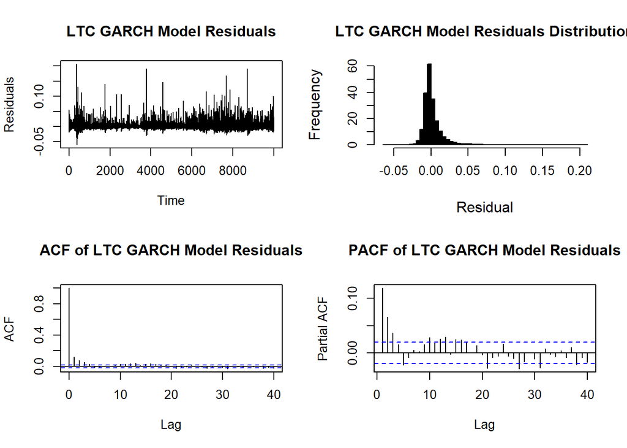

```r
par(mfrow = c(2, 2))

plot(LTC_garch_info$Residuals, type = "l", xlab = "Time", ylab = "Residuals", main = "LTC GARCH Model Residuals")
hist(LTC_garch_info$Residuals, main = "LTC GARCH Model Residuals Distribution", breaks = 50, col = "black", prob = TRUE, xlab = "", ylab = "")
mtext("Frequency", side = 2, line = 3.5, cex = 1)
mtext("Residual", side = 1, line = 3.5, cex = 1, outer = FALSE)
acf(LTC_garch_info$Residuals, main = "ACF of LTC GARCH Model Residuals", cex.axis = 1, cex.lab = 1)
pacf(LTC_garch_info$Residuals, main = "PACF of LTC GARCH Model Residuals", cex.axis = 1, cex.lab = 1)
```

```r
par(mfrow = c(1, 1))
```

**XRP/USD**

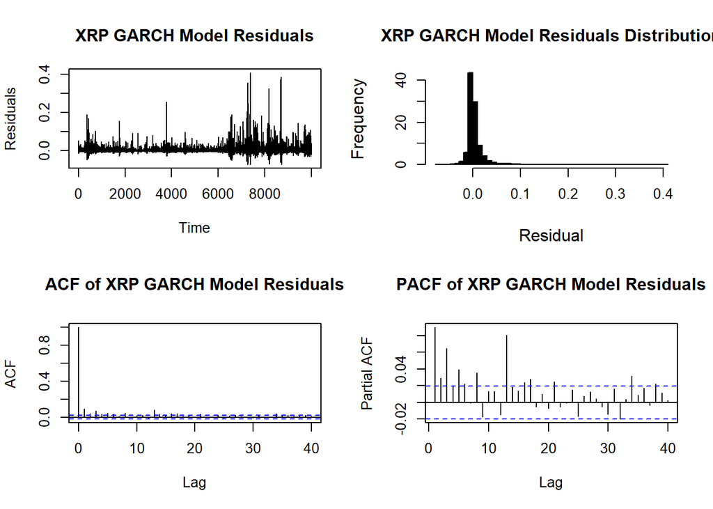

```r
par(mfrow = c(2, 2))

plot(XRP_garch_info$Residuals, type = "l", xlab = "Time", ylab = "Residuals", main = "XRP GARCH Model Residuals")
hist(XRP_garch_info$Residuals, main = "XRP GARCH Model Residuals Distribution", breaks = 50, col = "black", prob = TRUE, xlab = "", ylab = "")
mtext("Frequency", side = 2, line = 3.5, cex = 1)
mtext("Residual", side = 1, line = 3.5, cex = 1, outer = FALSE)
acf(XRP_garch_info$Residuals, main = "ACF of XRP GARCH Model Residuals", cex.axis = 1, cex.lab = 1)
pacf(XRP_garch_info$Residuals, main = "PACF of XRP GARCH Model Residuals", cex.axis = 1, cex.lab = 1)
```

```r
par(mfrow = c(1, 1))
```

**BCH/USD**

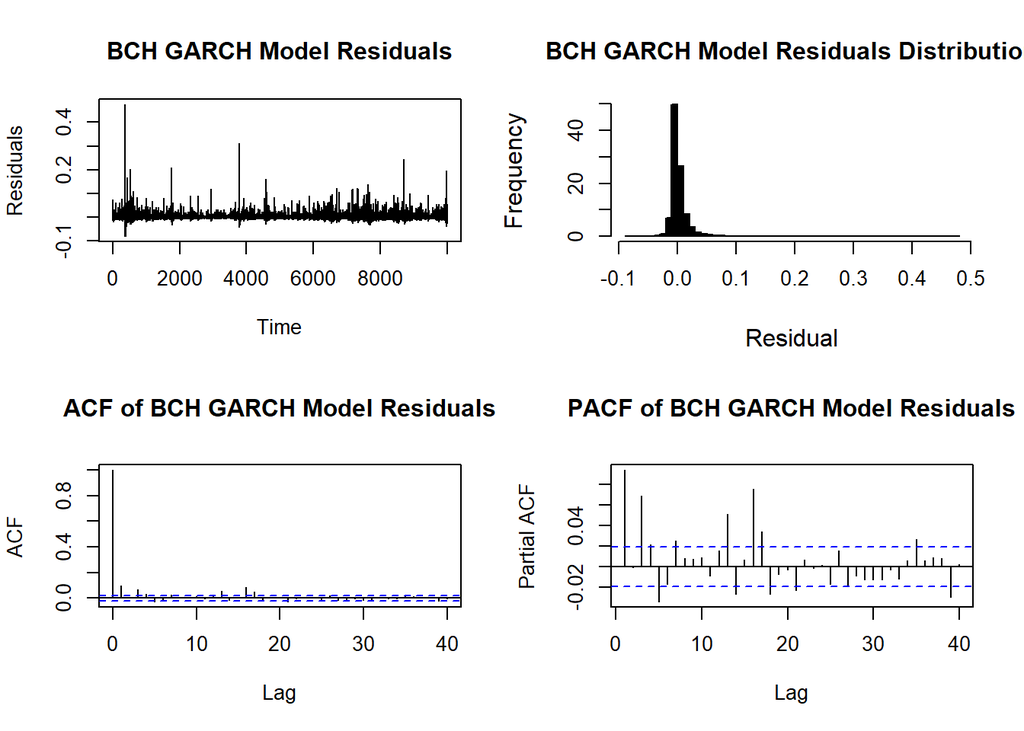

```r
par(mfrow = c(2, 2))

plot(BCH_garch_info$Residuals, type = "l", xlab = "Time", ylab = "Residuals", main = "BCH GARCH Model Residuals")
hist(BCH_garch_info$Residuals, main = "BCH GARCH Model Residuals Distribution", breaks = 50, col = "black", prob = TRUE, xlab = "", ylab = "")
mtext("Frequency", side = 2, line = 3.5, cex = 1)
mtext("Residual", side = 1, line = 3.5, cex = 1, outer = FALSE)
acf(BCH_garch_info$Residuals, main = "ACF of BCH GARCH Model Residuals", cex.axis = 1, cex.lab = 1)
pacf(BCH_garch_info$Residuals, main = "PACF of BCH GARCH Model Residuals", cex.axis = 1, cex.lab = 1)
```

```r
par(mfrow = c(1, 1))
```

## 4.2- ARIMA State-Space Models with Kalman Filter residuals

**BTC/USD**

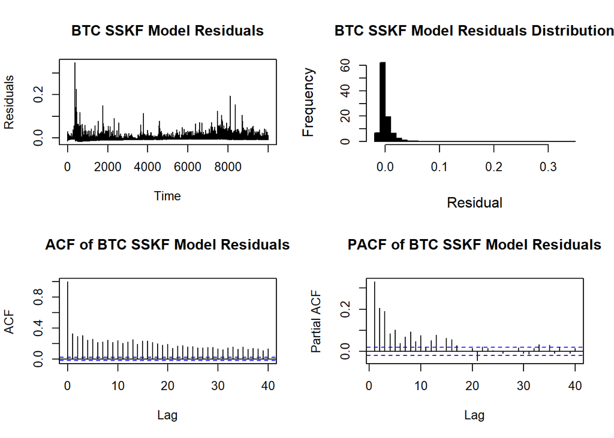

```r
par(mfrow = c(2, 2))

plot(BTC_SSKF_info$Residuals, type = "l", xlab = "Time", ylab = "Residuals", main = "BTC SSKF Model Residuals")
hist(BTC_SSKF_info$Residuals, main = "BTC SSKF Model Residuals Distribution", breaks = 50, col = "black", prob = TRUE, xlab = "", ylab = "")
mtext("Frequency", side = 2, line = 3.5, cex = 1)
mtext("Residual", side = 1, line = 3.5, cex = 1, outer = FALSE)
acf(BTC_SSKF_info$Residuals, main = "ACF of BTC SSKF Model Residuals", cex.axis = 1, cex.lab = 1)
pacf(BTC_SSKF_info$Residuals, main = "PACF of BTC SSKF Model Residuals", cex.axis = 1, cex.lab = 1)
```

```r
par(mfrow = c(1, 1))
```

**ETH/USD**

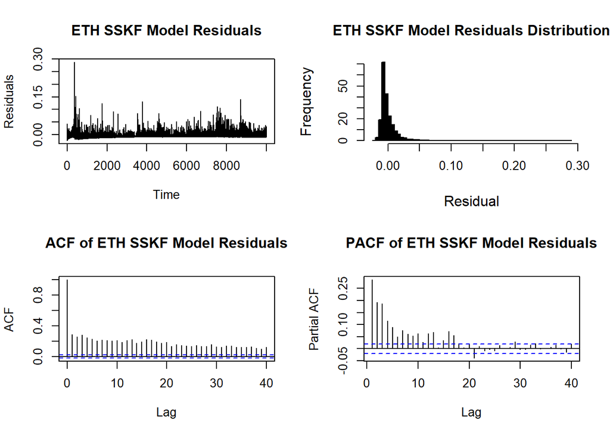

```r
par(mfrow = c(2, 2))

plot(ETH_SSKF_info$Residuals, type = "l", xlab = "Time", ylab = "Residuals", main = "ETH SSKF Model Residuals")
hist(ETH_SSKF_info$Residuals, main = "ETH SSKF Model Residuals Distribution", breaks = 50, col = "black", prob = TRUE, xlab = "", ylab = "")
mtext("Frequency", side = 2, line = 3.5, cex = 1)
mtext("Residual", side = 1, line = 3.5, cex = 1, outer = FALSE)
acf(ETH_SSKF_info$Residuals, main = "ACF of ETH SSKF Model Residuals", cex.axis = 1, cex.lab = 1)
pacf(ETH_SSKF_info$Residuals, main = "PACF of ETH SSKF Model Residuals", cex.axis = 1, cex.lab = 1)
```

```r
par(mfrow = c(1, 1))
```

**LTC/USD**

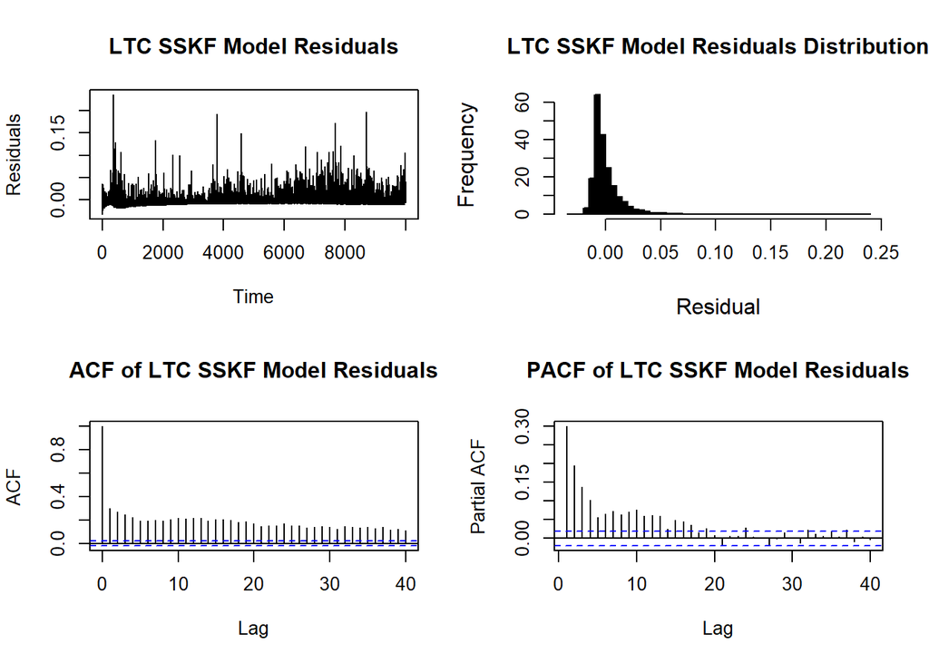

```r
par(mfrow = c(2, 2))

plot(LTC_SSKF_info$Residuals, type = "l", xlab = "Time", ylab = "Residuals", main = "LTC SSKF Model Residuals")
hist(LTC_SSKF_info$Residuals, main = "LTC SSKF Model Residuals Distribution", breaks = 50, col = "black", prob = TRUE, xlab = "", ylab = "")
mtext("Frequency", side = 2, line = 3.5, cex = 1)
mtext("Residual", side = 1, line = 3.5, cex = 1, outer = FALSE)
acf(LTC_SSKF_info$Residuals, main = "ACF of LTC SSKF Model Residuals", cex.axis = 1, cex.lab = 1)
pacf(LTC_SSKF_info$Residuals, main = "PACF of LTC SSKF Model Residuals", cex.axis = 1, cex.lab = 1)
```

```r
par(mfrow = c(1, 1))
```

**XRP/USD**

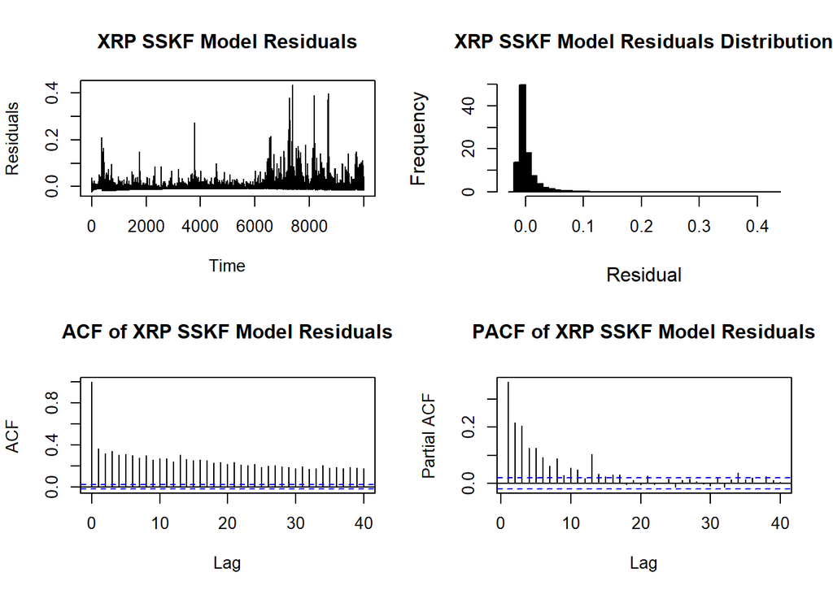

```r
par(mfrow = c(2, 2))

plot(XRP_SSKF_info$Residuals, type = "l", xlab = "Time", ylab = "Residuals", main = "XRP SSKF Model Residuals")
hist(XRP_SSKF_info$Residuals, main = "XRP SSKF Model Residuals Distribution", breaks = 50, col = "black", prob = TRUE, xlab = "", ylab = "")
mtext("Frequency", side = 2, line = 3.5, cex = 1)
mtext("Residual", side = 1, line = 3.5, cex = 1, outer = FALSE)
acf(XRP_SSKF_info$Residuals, main = "ACF of XRP SSKF Model Residuals", cex.axis = 1, cex.lab = 1)
pacf(XRP_SSKF_info$Residuals, main = "PACF of XRP SSKF Model Residuals", cex.axis = 1, cex.lab = 1)
```

```r
par(mfrow = c(1, 1))
```

**BCH/USD**

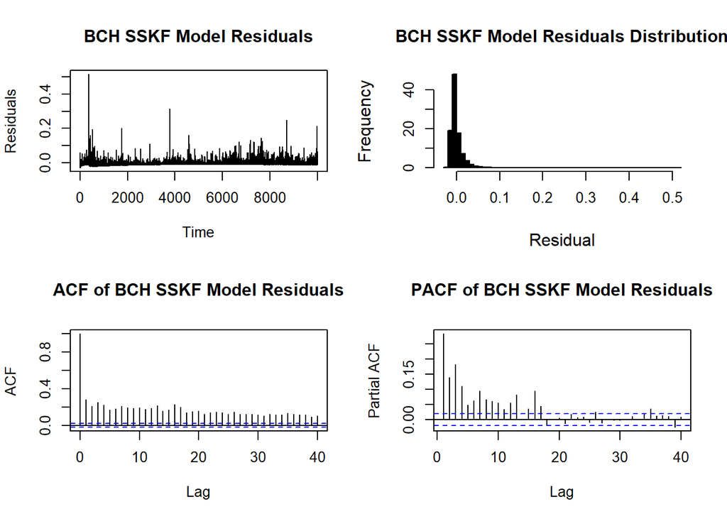

```r
par(mfrow = c(2, 2))

plot(BCH_SSKF_info$Residuals, type = "l", xlab = "Time", ylab = "Residuals", main = "BCH SSKF Model Residuals")
hist(BCH_SSKF_info$Residuals, main = "BCH SSKF Model Residuals Distribution", breaks = 50, col = "black", prob = TRUE, xlab = "", ylab = "")
mtext("Frequency", side = 2, line = 3.5, cex = 1)
mtext("Residual", side = 1, line = 3.5, cex = 1, outer = FALSE)
acf(BCH_SSKF_info$Residuals, main = "ACF of BCH SSKF Model Residuals", cex.axis = 1, cex.lab = 1)
pacf(BCH_SSKF_info$Residuals, main = "PACF of BCH SSKF Model Residuals", cex.axis = 1, cex.lab = 1)
```

```r
par(mfrow = c(1, 1))
```

## 4.3- Neural Network Autoregressive Models residuals

**BTC/USD**

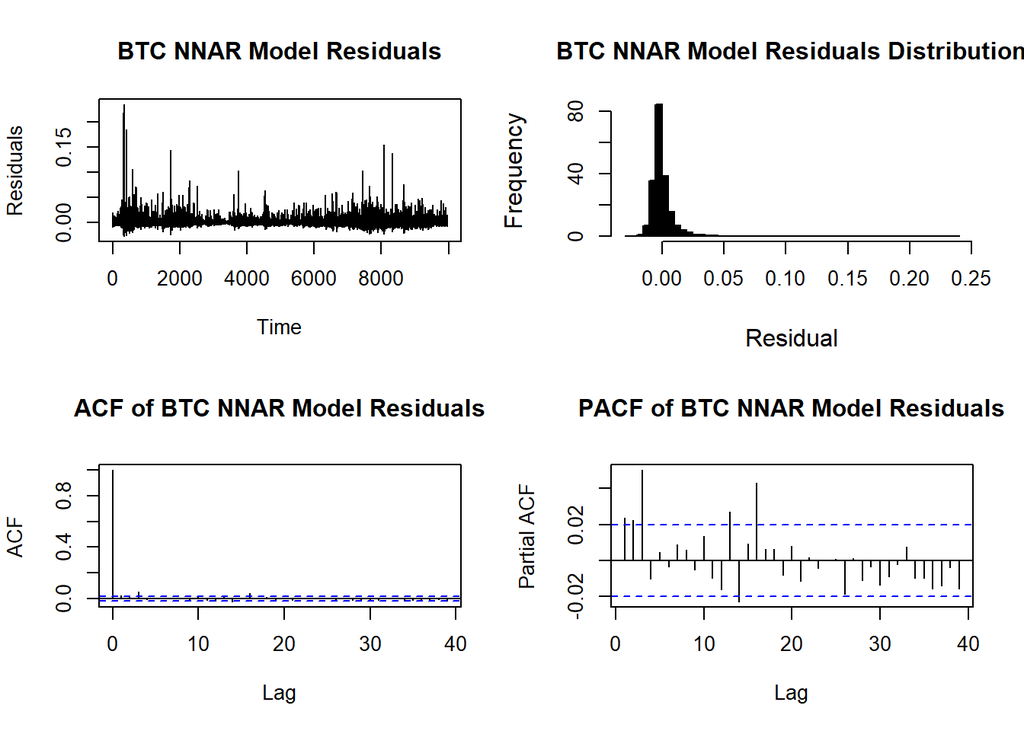

```r
par(mfrow = c(2, 2))

plot(BTC_NNAR_info$Residuals, type = "l", xlab = "Time", ylab = "Residuals", main = "BTC NNAR Model Residuals")
hist(BTC_NNAR_info$Residuals, main = "BTC NNAR Model Residuals Distribution", breaks = 50, col = "black", prob = TRUE, xlab = "", ylab = "")
mtext("Frequency", side = 2, line = 3.5, cex = 1)
mtext("Residual", side = 1, line = 3.5, cex = 1, outer = FALSE)
acf(BTC_NNAR_info$Residuals, main = "ACF of BTC NNAR Model Residuals", cex.axis = 1, cex.lab = 1)
pacf(BTC_NNAR_info$Residuals, main = "PACF of BTC NNAR Model Residuals", cex.axis = 1, cex.lab = 1)
```

```r
par(mfrow = c(1, 1))
```

**ETH/USD**

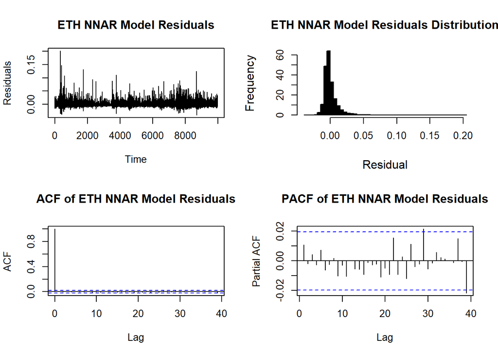

```r
par(mfrow = c(2, 2))

plot(ETH_NNAR_info$Residuals, type = "l", xlab = "Time", ylab = "Residuals", main = "ETH NNAR Model Residuals")
hist(ETH_NNAR_info$Residuals, main = "ETH NNAR Model Residuals Distribution", breaks = 50, col = "black", prob = TRUE, xlab = "", ylab = "")
mtext("Frequency", side = 2, line = 3.5, cex = 1)
mtext("Residual", side = 1, line = 3.5, cex = 1, outer = FALSE)
acf(ETH_NNAR_info$Residuals, main = "ACF of ETH NNAR Model Residuals", cex.axis = 1, cex.lab = 1)
pacf(ETH_NNAR_info$Residuals, main = "PACF of ETH NNAR Model Residuals", cex.axis = 1, cex.lab = 1)
```

```r
par(mfrow = c(1, 1))
```

**LTC/USD**

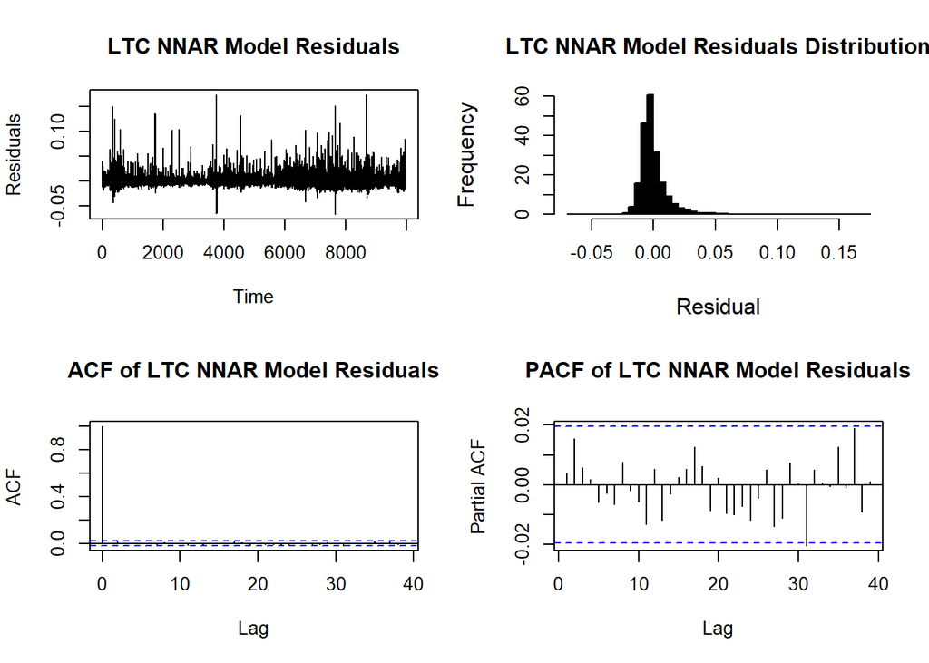

```r
par(mfrow = c(2, 2))

plot(LTC_NNAR_info$Residuals, type = "l", xlab = "Time", ylab = "Residuals", main = "LTC NNAR Model Residuals")
hist(LTC_NNAR_info$Residuals, main = "LTC NNAR Model Residuals Distribution", breaks = 50, col = "black", prob = TRUE, xlab = "", ylab = "")
mtext("Frequency", side = 2, line = 3.5, cex = 1)
mtext("Residual", side = 1, line = 3.5, cex = 1, outer = FALSE)
acf(LTC_NNAR_info$Residuals, main = "ACF of LTC NNAR Model Residuals", cex.axis = 1, cex.lab = 1)
pacf(LTC_NNAR_info$Residuals, main = "PACF of LTC NNAR Model Residuals", cex.axis = 1, cex.lab = 1)
```

```r
par(mfrow = c(1, 1))
```

**XRP/USD**

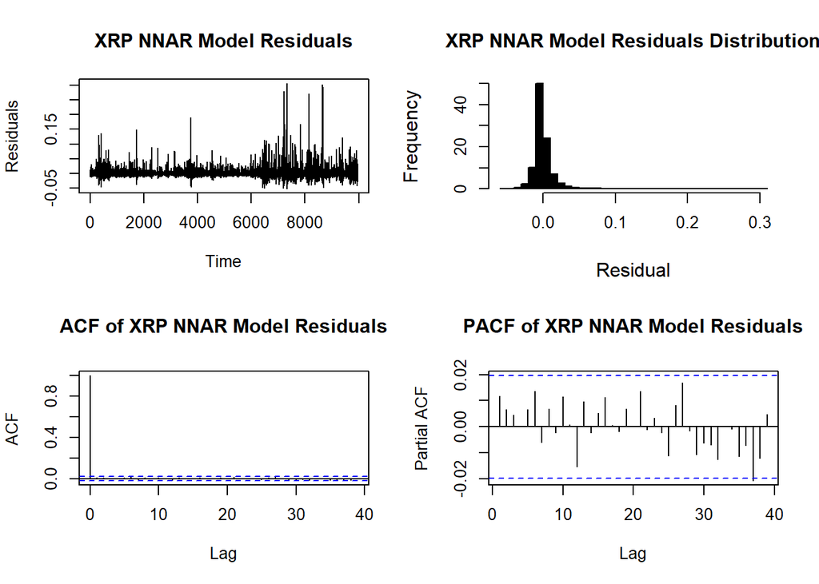

```r
par(mfrow = c(2, 2))

plot(XRP_NNAR_info$Residuals, type = "l", xlab = "Time", ylab = "Residuals", main = "XRP NNAR Model Residuals")
hist(XRP_NNAR_info$Residuals, main = "XRP NNAR Model Residuals Distribution", breaks = 50, col = "black", prob = TRUE, xlab = "", ylab = "")
mtext("Frequency", side = 2, line = 3.5, cex = 1)
mtext("Residual", side = 1, line = 3.5, cex = 1, outer = FALSE)
acf(XRP_NNAR_info$Residuals, main = "ACF of XRP NNAR Model Residuals", cex.axis = 1, cex.lab = 1)
pacf(XRP_NNAR_info$Residuals, main = "PACF of XRP NNAR Model Residuals", cex.axis = 1, cex.lab = 1)
```

```r
par(mfrow = c(1, 1))
```

**BCH/USD**

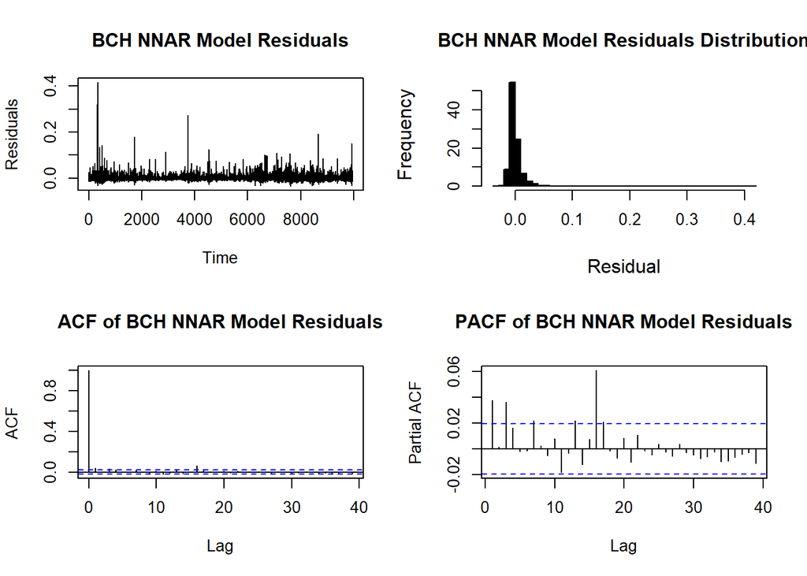

```r
par(mfrow = c(2, 2))

plot(BCH_NNAR_info$Residuals, type = "l", xlab = "Time", ylab = "Residuals", main = "BCH NNAR Model Residuals")
hist(BCH_NNAR_info$Residuals, main = "BCH NNAR Model Residuals Distribution", breaks = 50, col = "black", prob = TRUE, xlab = "", ylab = "")
mtext("Frequency", side = 2, line = 3.5, cex = 1)
mtext("Residual", side = 1, line = 3.5, cex = 1, outer = FALSE)
acf(BCH_NNAR_info$Residuals, main = "ACF of BCH NNAR Model Residuals", cex.axis = 1, cex.lab = 1)
pacf(BCH_NNAR_info$Residuals, main = "PACF of BCH NNAR Model Residuals", cex.axis = 1, cex.lab = 1)
```

```r
par(mfrow = c(1, 1))
```

# PART 5: Alpha cut for Value-at-Risk

## 5.1- GARCH Models VaR

We fix the order of the quantile of the t-student distribution used to compute the Value-at-Risk at 1%.

```r
alpha <- 0.01
alpha_confidence_interval<-seq(from=0.01, to=1, by=0.01)
l<-length(alpha_confidence_interval)
normal_critical_values<-rep(0, l)
for(i in 1:l) normal_critical_values[i]=qnorm(1-alpha_confidence_interval[i]/2, mean=0, sd=1)
```

**BTC/USD**

```r
BTC_degree_freedom <- coef(BTC_garch_info$Model)["shape"]
BTC_critical_value <- qt(alpha, df=BTC_degree_freedom)
BTC_garch_VaR <- 10000*sqrt((BTC_degree_freedom-2)/BTC_degree_freedom)*BTC_garch_info$Forecast*BTC_critical_value

BTC_SE_residuals_garch <- BTC_garch_info$RMSE/sqrt(10000)
```

**ETH/USD**

```r
ETH_degree_freedom <- coef(ETH_garch_info$Model)["shape"]
ETH_critical_value <- qt(alpha, df=ETH_degree_freedom)
ETH_garch_VaR <- 10000*sqrt((ETH_degree_freedom-2)/ETH_degree_freedom)*ETH_garch_info$Forecast*ETH_critical_value

ETH_SE_residuals_garch <- ETH_garch_info$RMSE/sqrt(10000)
```

**LTC/USD**

```r
LTC_degree_freedom <- coef(LTC_garch_info$Model)["shape"]
LTC_critical_value <- qt(alpha, df=LTC_degree_freedom)
LTC_garch_VaR <- 10000*sqrt((LTC_degree_freedom-2)/LTC_degree_freedom)*LTC_garch_info$Forecast*LTC_critical_value

LTC_SE_residuals_garch <- LTC_garch_info$RMSE/sqrt(10000)
```

**XRP/USD**

```r
XRP_degree_freedom <- coef(XRP_garch_info$Model)["shape"]
XRP_critical_value <- qt(alpha, df=XRP_degree_freedom)
XRP_garch_VaR <- 10000*sqrt((XRP_degree_freedom-2)/XRP_degree_freedom)*XRP_garch_info$Forecast*XRP_critical_value

XRP_SE_residuals_garch <- XRP_garch_info$RMSE/sqrt(10000)
```

**BCH/USD**

```r
BCH_degree_freedom <- coef(BCH_garch_info$Model)["shape"]
BCH_critical_value <- qt(alpha, df=BCH_degree_freedom)
BCH_garch_VaR <- 10000*sqrt((BCH_degree_freedom-2)/BCH_degree_freedom)*BCH_garch_info$Forecast*BCH_critical_value

BCH_SE_residuals_garch <- BCH_garch_info$RMSE/sqrt(10000)
```

## 5.2- ARIMA State-Space Models with Kalman Filter VaR

**BTC/USD**

```r
BTC_SSKF_VaR <- as.vector(10000*sqrt((BTC_degree_freedom-2)/BTC_degree_freedom)*BTC_SSKF_info$Forecast*BTC_critical_value)

BTC_SE_residuals_SSKF <- BTC_SSKF_info$RMSE/sqrt(10000)
```

**ETH/USD**

```r
ETH_SSKF_VaR <- as.vector(10000*sqrt((ETH_degree_freedom-2)/ETH_degree_freedom)*ETH_SSKF_info$Forecast*ETH_critical_value)

ETH_SE_residuals_SSKF <- ETH_SSKF_info$RMSE/sqrt(10000)
```

**LTC/USD**

```r
LTC_SSKF_VaR <- as.vector(10000*sqrt((LTC_degree_freedom-2)/LTC_degree_freedom)*LTC_SSKF_info$Forecast*LTC_critical_value)

LTC_SE_residuals_SSKF <- LTC_SSKF_info$RMSE/sqrt(10000)
```

**XRP/USD**

```r
XRP_SSKF_VaR <- as.vector(10000*sqrt((XRP_degree_freedom-2)/XRP_degree_freedom)*XRP_SSKF_info$Forecast*XRP_critical_value)

XRP_SE_residuals_SSKF <- XRP_SSKF_info$RMSE/sqrt(10000)
```

## 5.3- Neural Network Autoregressive Models VaR

**BTC/USD**

```r
BTC_NNAR_VaR<--10000*sqrt((BTC_degree_freedom-2)/BTC_degree_freedom)*BTC_NNAR_info$Forecast*BTC_critical_value

BTC_SE_residuals_NNAR <- BTC_NNAR_info$RMSE/sqrt(10000)
```

**ETH/USD**

```r
ETH_NNAR_VaR<--10000*sqrt((ETH_degree_freedom-2)/ETH_degree_freedom)*ETH_NNAR_info$Forecast*ETH_critical_value

ETH_SE_residuals_NNAR <- ETH_NNAR_info$RMSE/sqrt(10000)
```

**LTC/USD**

```r
LTC_NNAR_VaR<--10000*sqrt((LTC_degree_freedom-2)/LTC_degree_freedom)*LTC_NNAR_info$Forecast*LTC_critical_value

LTC_SE_residuals_NNAR <- LTC_NNAR_info$RMSE/sqrt(10000)
```

**XRP/USD**

```r
XRP_NNAR_VaR<--10000*sqrt((XRP_degree_freedom-2)/XRP_degree_freedom)*XRP_NNAR_info$Forecast*XRP_critical_value

XRP_SE_residuals_NNAR <- XRP_NNAR_info$RMSE/sqrt(10000)
```

**BCH/USD**

```r
BCH_NNAR_VaR<--10000*sqrt((BCH_degree_freedom-2)/BCH_degree_freedom)*BCH_NNAR_info$Forecast*BCH_critical_value

BCH_SE_residuals_NNAR <- BCH_NNAR_info$RMSE/sqrt(10000)
```

## 5.4- Volatility forecast confidence interval

We create a function to compute the confidence interval of the volatility forecast of the different models and display them on a single chart to compare the accuracy of the models.

```r
volitility_confidence_interval<-function(volatilities,standard_errors,name){

  interval_GC<-as.data.frame(matrix(0, ncol=2, nrow=l))
  colnames(interval_GC)<-c("lower", "upper")
  rownames(interval_GC)<-as.character(percent(1-alpha_confidence_interval))

  interval_NNAR<-as.data.frame(matrix(0, ncol=2, nrow=l))
  colnames(interval_NNAR)<-c("lower", "upper")
  rownames(interval_NNAR)<-as.character(percent(1-alpha_confidence_interval))

  interval_SSKF<-as.data.frame(matrix(0, ncol=2, nrow=l))
  colnames(interval_SSKF)<-c("lower", "upper")
  rownames(interval_SSKF)<-as.character(percent(1-alpha_confidence_interval))

  mean<-(volatilities[1]+volatilities[2]+volatilities[3])/3

  for(i in 1:l){
    interval_GC[i, ]<-c(mean-normal_critical_values[i]*standard_errors[1],
                        mean+normal_critical_values[i]*standard_errors[1])

    interval_SSKF[i, ]<-c(mean-normal_critical_values[i]*standard_errors[2],
                          mean+normal_critical_values[i]*standard_errors[2])

    interval_NNAR[i, ]<-c(mean-normal_critical_values[i]*standard_errors[3],
                          mean+normal_critical_values[i]*standard_errors[3])
  }

  plot(interval_GC[,1], alpha_confidence_interval, xlab=expression(sigma), type="l",
     ylab=expression(alpha), xlim=c(min(interval_SSKF)-0.001, max(interval_SSKF)+0.001),
     col="yellow", main=paste("Volatility forecast confidence intervals for",name),
     lty=1, lwd=3)

    lines(interval_GC[, 2], alpha_confidence_interval,
          col="yellow", lty=1, lwd=3)
    lines(interval_NNAR[, 1], alpha_confidence_interval,
          col="red", lty=2, lwd=2)
    lines(interval_NNAR[, 2], alpha_confidence_interval,
          col="red", lty=2, lwd=2)
    lines(interval_SSKF[, 1], alpha_confidence_interval,
          col="purple", lty=2, lwd=3)
    lines(interval_SSKF[, 2], alpha_confidence_interval,
          col="purple", lty=2, lwd=3)

    legend("topright",c("GARCH (1,1)","NNAR", "SS-KF"),
          lty=c(1,1,2),lwd=c(3,3,3),pt.cex=0.9,
          col=c("yellow","red","purple"), cex=0.5)

    return(c(
      interval_GC,
      interval_SSKF,
      interval_NNAR
    ))
}
```

**BTC/USD**

```r
BTC_volatilities<-c(BTC_garch_info$Forecast,
                    BTC_SSKF_info$Forecast,
                    BTC_NNAR_info$Forecast)

BTC_standard_errors<-c(BTC_SE_residuals_garch,
                       BTC_SE_residuals_SSKF,
                       BTC_SE_residuals_NNAR)

BTC_volatility_forecast_CI <- volitility_confidence_interval(BTC_volatilities,BTC_standard_errors,"Bitcoin")
```

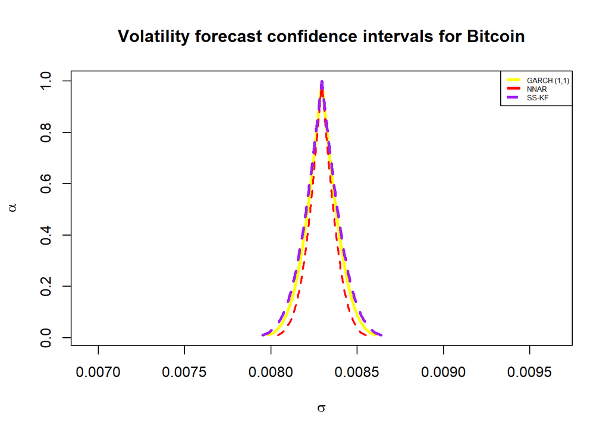

```r
ETH_volatilities<-c(ETH_garch_info$Forecast,
                    ETH_SSKF_info$Forecast,
                    ETH_NNAR_info$Forecast)

ETH_standard_errors<-c(ETH_SE_residuals_garch,
                       ETH_SE_residuals_SSKF,
                       ETH_SE_residuals_NNAR)

ETH_volatility_forecast_CI <- volitility_confidence_interval(ETH_volatilities,ETH_standard_errors,"Ether")
```

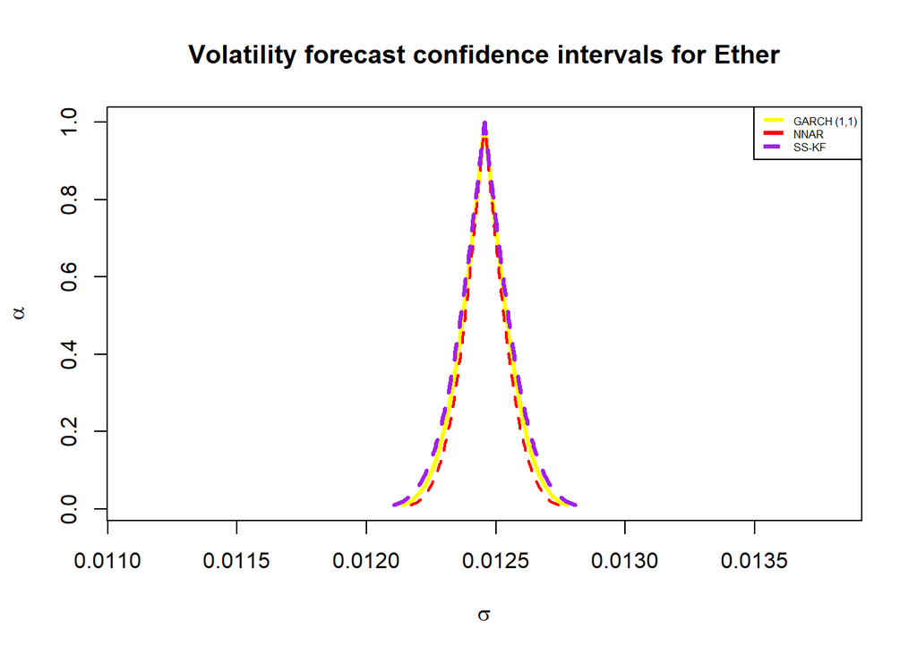

[figure not shown]

```r
XRP_volatilities<-c(XRP_garch_info$Forecast,
                    XRP_SSKF_info$Forecast,
                    XRP_NNAR_info$Forecast)

XRP_standard_errors<-c(XRP_SE_residuals_garch,
                       XRP_SE_residuals_SSKF,
                       XRP_SE_residuals_NNAR)

XRP_volatility_forecast_CI <- volitility_confidence_interval(XRP_volatilities,XRP_standard_errors,"Ripples")
```

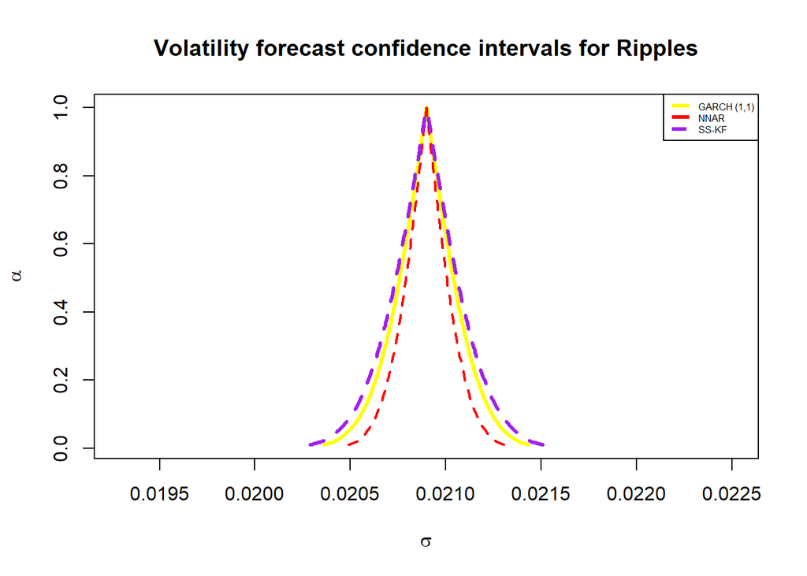

[figure not shown]

## 5.5- Value-at-Risk forecast confiance interval

With the same logic of the previous section, we construct a function to compute the confidence interval of the Value-at-Risk forecast of the different models and display them on a single chart to compare the accuracy of the models.

```r
VaR_confidence_interval<-function(VaR,standard_errors,intervals,critical_value,freedom_degree,name){

  interval_GC_VaR<-as.data.frame(matrix(0, ncol=2, nrow=l))
  colnames(interval_GC_VaR)<-c("lower", "upper")
  rownames(interval_GC_VaR)<-as.character(percent(1-alpha_confidence_interval))

  interval_NNAR_VaR<-as.data.frame(matrix(0, ncol=2, nrow=l))
  colnames(interval_NNAR_VaR)<-c("lower", "upper")
  rownames(interval_NNAR_VaR)<-as.character(percent(1-alpha_confidence_interval))

  interval_SSKF_VaR<-as.data.frame(matrix(0, ncol=2, nrow=l))
  colnames(interval_SSKF_VaR)<-c("lower", "upper")
  rownames(interval_SSKF_VaR)<-as.character(percent(1-alpha_confidence_interval))

  mean<-(VaR[1]+VaR[2]+VaR[3])/3

  for(i in 1:l){
    interval_GC_VaR[i,]<-c(intervals[[1]][i]*(-10000)*critical_value*sqrt((freedom_degree-2)/freedom_degree),
                           intervals[[2]][i]*(-10000)*critical_value*sqrt((freedom_degree-2)/freedom_degree))

    interval_SSKF_VaR[i,]<-c(intervals[[3]][i]*(-10000)*critical_value*sqrt((freedom_degree-2)/freedom_degree),
                             intervals[[4]][i]*(-10000)*critical_value*sqrt((freedom_degree-2)/freedom_degree))

    interval_NNAR_VaR[i,]<-c(intervals[[5]][i]*(-10000)*critical_value*sqrt((freedom_degree-2)/freedom_degree),
                             intervals[[6]][i]*(-10000)*critical_value*sqrt((freedom_degree-2)/freedom_degree))
  }

  plot(interval_GC_VaR[,1], alpha_confidence_interval, xlab=expression(sigma), type="l",
     ylab=expression(alpha), xlim=c(min(interval_SSKF_VaR)-0.001, max(interval_SSKF_VaR)+0.001),
     col="yellow", main=paste("Value-at-Risk forecast confidence intervals for",name),
     lty=1, lwd=3)

    lines(interval_GC_VaR[, 2], alpha_confidence_interval,
          col="yellow", lty=1, lwd=3)
    lines(interval_NNAR_VaR[, 1], alpha_confidence_interval,
          col="red", lty=2, lwd=2)
    lines(interval_NNAR_VaR[, 2], alpha_confidence_interval,
          col="red", lty=2, lwd=2)
    lines(interval_SSKF_VaR[, 1], alpha_confidence_interval,
          col="purple", lty=2, lwd=3)
    lines(interval_SSKF_VaR[, 2], alpha_confidence_interval,
          col="purple", lty=2, lwd=3)

    legend("topright",c("GARCH (1,1)","NNAR", "SS-KF"),
          lty=c(1,1,2),lwd=c(3,3,3),pt.cex=0.9,
          col=c("yellow","red","purple"), cex=0.5)
}
```

**BTC/USD**

```r
BTC_VaR<-c(BTC_garch_VaR,
           BTC_SSKF_VaR,
           BTC_NNAR_VaR)

BTC_SE<-c(BTC_SE_residuals_garch,
          BTC_SE_residuals_SSKF,
          BTC_SE_residuals_NNAR)


BTC_VaR_forecast_CI<-VaR_confidence_interval(BTC_VaR,
                                             BTC_SE,
                                             BTC_volatility_forecast_CI,
                                             BTC_critical_value,
                                             BTC_degree_freedom,
                                             "Bitcoin")
```

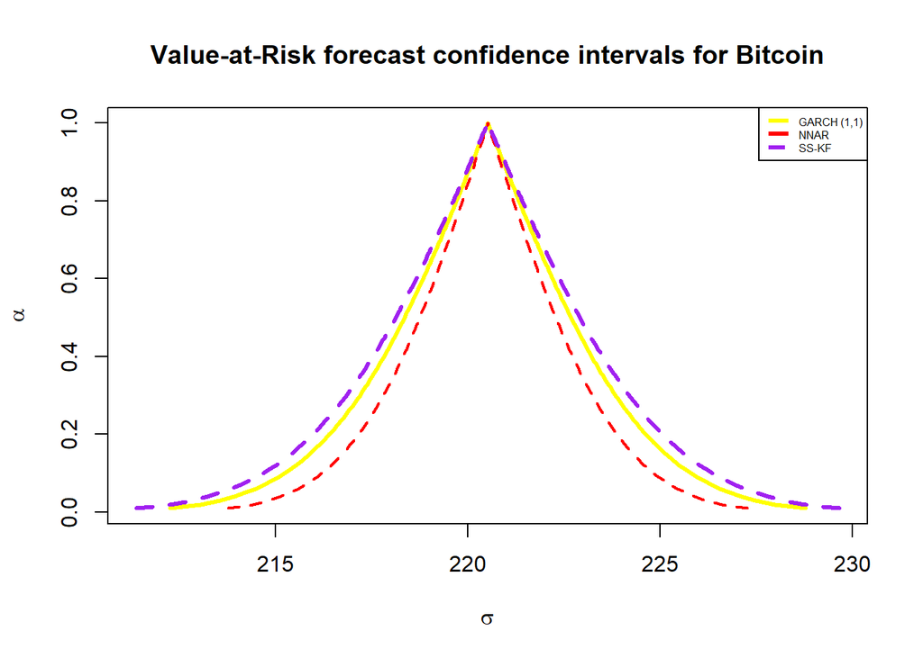

**ETH/USD**

```r
ETH_VaR<-c(ETH_garch_VaR,
           ETH_SSKF_VaR,
           ETH_NNAR_VaR)

ETH_SE<-c(ETH_SE_residuals_garch,
          ETH_SE_residuals_SSKF,
          ETH_SE_residuals_NNAR)


ETH_VaR_forecast_CI<-VaR_confidence_interval(ETH_VaR,
                                             ETH_SE,
                                             ETH_volatility_forecast_CI,
                                             ETH_critical_value,
                                             ETH_degree_freedom,
                                             "Ether")
```

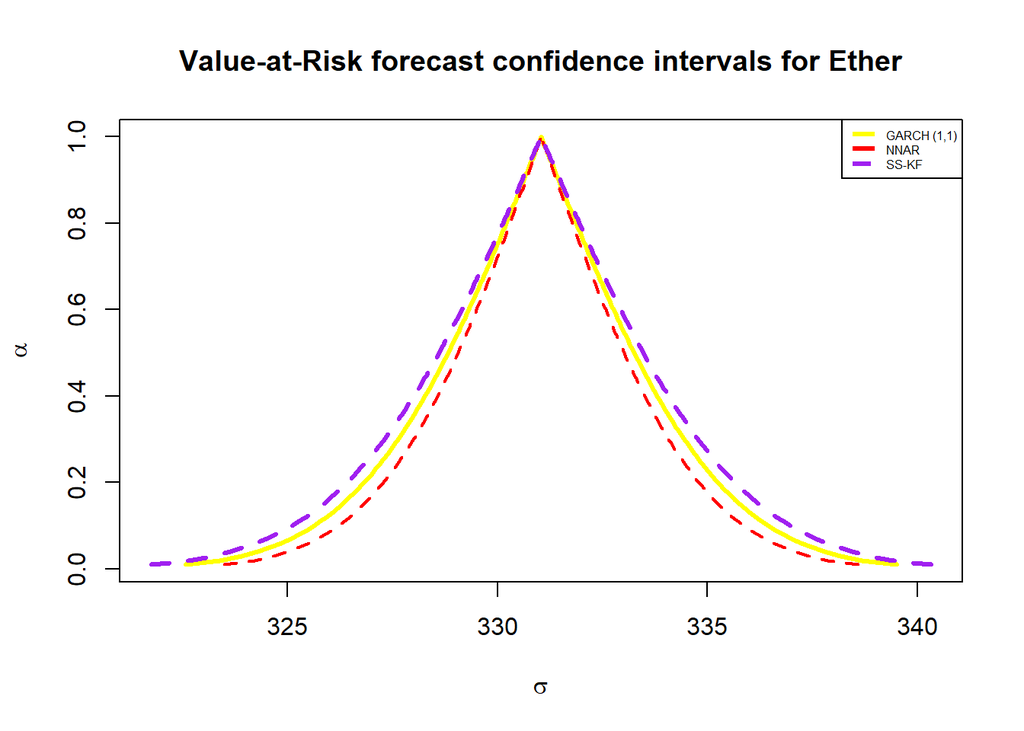

**LTC/USD**